# Objects and Classes, Constructors

### Where storage lives

It’s useful to visualize the way things are laid out while the program is running—in particular, how memory is arranged. There are different places to store data:

##### Registers

This is the fastest storage because it exists in a place different from that of other storage: inside the central processing unit. However, the number of registers is severely limited, so registers are allocated as they are needed. You don’t have direct control over register allocation, nor do you see any evidence in your programs that registers even exist.

##### The Stack

This lives in the general random-access memory (RAM) area, but has direct support from the processor via its stack pointer . The stack pointer is moved down to create new memory and moved up to release that memory. This is an extremely fast and efficient way to allocate storage, second only to registers. The Java system must know, while it is creating the program, the exact lifetime of all the items stored on the stack. This constraint places limits on the flexibility of your programs, so while some Java storage exists on the stack—in particular, object references—Java objects themselves are not placed on the stack.

##### The heap

This is a general-purpose pool of memory (also in the RAM area) where all Java objects live. Unlike the stack, the compiler doesn’t need to know how long objects must stay on the heap. Thus, there’s a great deal of flexibility when using heap storage. Whenever you need an object, you write the code to create it using new , and the storage is allocated on the heap when that code is executed.

##### Non-RAM storage

If data lives completely outside a program, it can exist while the program is not running, outside the control of the program. The two primary examples of this are serialized objects , where objects are turned into streams of bytes, generally sent to another machine, and persistent objects , where the objects are placed on disk so they will hold their state even when the program is terminated.

### new

The **new** operator dynamically allocates memory for an object. In the context of an assignment, it has this general form: *class-var = new classname ( );*

class-var - is a certain class reference variable that will refer to the created object. The classname is the name of the class that is being instantiated. The class name followed by parentheses specifies the constructor for the class. Constructors are an important part of all classes and have many significant attributes. Most real-world classes explicitly define their own constructors within their class definition. However, if no explicit constructor is specified, then Java will automatically supply a default constructor.

```java
class A {
    // no constructors is explicitly specified
}
```

```java
A a = new A(); // OK, because default constructor will be generated.
```

At this point, you might be wondering why you do not need to use new for such things as integers or characters. The answer is that Java’s primitive types are **not implemented as objects**. Later, you will see object versions of the primitive types that are available for your use in those situations in which complete objects of these types are needed.

It is important to understand that **new** allocates memory for an object during run time. The advantage of this approach is that your program can create as many or as few objects as it needs during the execution of your program.

Let’s once again review the distinction between a `class` and an `object`. A class creates a new data type that can be used to create objects. That is, a class creates a logical framework that defines the relationship between its members. When you declare an object of a class, you are creating an instance of that class. Thus, a class is a logical construct. An object has physical reality.

### Object reference variables

Object reference variables act differently than you might expect when an assignment takes place. For example:

```java
class AbraKadabra {
    int a = 100;
}
```

```java
AbraKadabra abra = new AbraKadabra();
AbraKadabra kadabra = abra;
abra.a = 200;
System.out.println(abra.a);
System.out.println(kadabra.a);
```

```
200
200
```

After these line of code one object will be created in memory, but 2 variables "abra" and "kadabra" will be pointed on it.

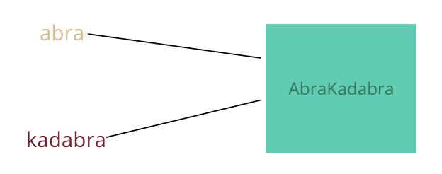

But these variables are not linked together. For example:

```java
kadabra = new AbraKadabra();
System.out.println(kadabra.a);
System.out.println(abra.a);
```

```
100
200
```

After this line these two variables will be pointed to different objects.

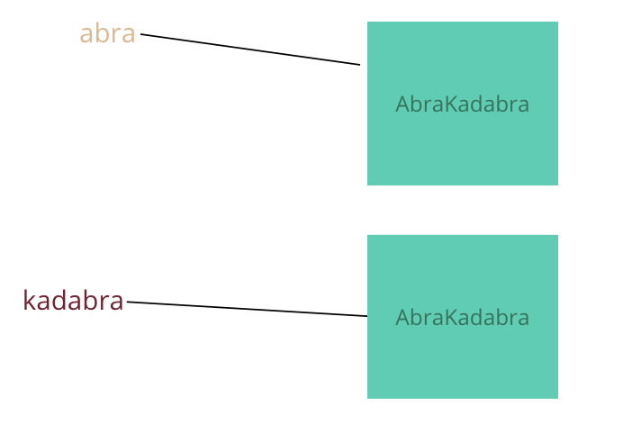

### Constructors

It can be tedious to initialize all of the variables in a class each time an instance is created. It would be simpler and more concise to have all of the setup done at the time the object is first created. Because the requirement for initialization is so common, Java allows objects to initialize themselves when they are created. This automatic initialization is performed through the use of a **constructor**.

A constructor initializes an object immediately upon creation. It has the same name as the class in which it resides and is syntactically similar to a method. Once defined, the constructor is automatically called when the object is created, before the **new** operator completes.

```java
class MyClass {}
MyClass myClass = new MyClass(); // default constructor will be called.
```

Constructors look a little strange because they have no return type, not even void. This is because the implicit return type of a class’ constructor is the class type itself. It is the constructor’s job to initialize the internal state of an object so that the code creating an instance will have a fully initialized, usable object immediately.

```java
class Box {
    int width;
    int height;
    int depth;

    public Box() {
        System.out.println("No args constructor Box()");
        width = 10;
        height = 10;
        depth = 10;
    }

    public double getVolume() {
        return width * height * depth;
    }
}
```

```java
Box box = new Box();
```

```
No args constructor Box()
```

```java
box.height
```

```
10
```

```java
box.width
```

```
10
```

```java
box.depth
```

```
10
```

```java
box.getVolume();
```

```
1000.0
```

As you can see, box variable was initialized by the Box() constructor when it was created. Since the constructor gives all boxes the same dimensions, 10 by 10 by 10, box will have the same volume for every object you create.

Now you can understand why the parentheses are needed after the class name. What is actually happening is that the constructor for the class is being called. The line

```java
Box box = new Box();
```

```
No args constructor Box()
```

is calling the Box( ) constructor.|

The default constructor is often sufficient for simple classes, but it usually won’t do for more sophisticated ones. Once you define your own constructor, the default constructor is no longer used.

> Caution:

> Please keep in mind that you get a free no-argument constructor only when your class has no other constructors. If you write your class with even a single constructor of your own and you want the users of your class to have the ability to create an instance by a call to `new ClassName()` then you must provide a no-argument constructor explicitly.

#### Parameterized constructors

While the Box() constructor in the preceding example does initialize a Box object, it is not very useful—all boxes have the same dimensions. What is needed is a way to construct Box objects of various dimensions. The easy solution is to add parameters to the constructor.

```java
class NewBox {

    double height;
    double width;
    double depth;

    public NewBox(double h, double w, double d) {
        height = h;
        width = w;
        depth = d;
    }

    public double getVolume() {
        return width * height * depth;
    }

}
```

```java
NewBox myNewBox = new NewBox(); // will throw an exception because no default constructor was provided.
```

```
|   NewBox myNewBox = new NewBox(); // will throw an exception because no default constructor was provided.
constructor NewBox in class NewBox cannot be applied to given types;
  required: double,double,double
  found: no arguments
  reason: actual and formal argument lists differ in length
```

```java
NewBox myNewBox = new NewBox(5, 10, 15);
```

```java
myNewBox.getVolume();
```

```
750.0
```

As you can see, each object is initialized as specified in the parameters to its constructor.

#### "this" keyword

Sometimes a method will need to refer to the object that invoked it. To allow this, Java defines the **this** keyword. This is always a reference to the object on which the method was invoked.

So, why do we need to use it? Let's consider one example:

As you know, it is illegal in Java to declare two local variables with the same name inside the same or enclosing scopes. Interestingly, you can have local variables, including formal parameters to methods, which overlap with the names of the class’ instance variables.

```java
class NewBox2 {

    double height;
    double width;
    double depth;

    public NewBox2(double height, double width, double depth) {
        height = height;
        width = width;
        depth = depth;
    }

    public double getVolume() {
        return width * height * depth;
    }

}
```

```java
NewBox2 nb = new NewBox2(1, 2, 3);
```

```java
nb.getVolume();
```

```
0.0
```

```java
class NewBox2 {

    double height;
    double width;
    double depth;

    public NewBox2(double h, double w, double d) {
        height = h;
        width = w;
        depth = d;
    }

    public double getVolume() {
        return width * height * depth;
    }

}
```

```java
NewBox2 nb = new NewBox2(1, 2, 3);
nb.getVolume();
```

```
6.0
```

#### Calling another constructor

**this** keyword has a second meaning. If the first statement has the form `this(...)`, then the constructor calls another constructor of the same class. For example:

```java
public class Cat {
    int age;
    int weight;
    String name;

    public Cat(String name) {
        this.name = name;
        System.out.println("1 Args cons");
    }

    public Cat(String name, int age) {
        this(name);
        this.age = age;
        System.out.println("2 Args cons");
    }

    public Cat(String name, int age, int weight) {
        this(name, age);
        this.weight = weight;
        System.out.println("3 Args cons");
    }
}
```

[output not shown]

```java
Cat cat = new Cat("George", 10, 20);
```

```
1 Args cons
2 Args cons
3 Args cons
```

Using the this keyword in this manner is useful—you only need to write common construction code once.

### Initialization blocks

You have already seen two ways to initialize a data field:  
1) By setting a value in a constructor;  
2) By assigning a value in the declaration.

There is a third mechanism in Java, called an **initialization block**.

```java
class A {
    double a = 10;
    double b = 10;
}
```

These blocks are executed whenever an object of that class is constructed. For example:

```java
class Employee {
    public static int nextId = 0;
    private int id = 0;
    private String name = null;
    private double salary = 0.0;
    // object initialization block
    {
        System.out.println("Inside initialization block");
        id = nextId;
        nextId++;
    }

    public Employee(String name, double salary) {
        System.out.println("Inside Employee(String, double) constructor");
        this.name = name;
        this.salary = salary;
    }

    public Employee() {
        System.out.println("Inside empty constructor");
        this.name = "";
        this.salary = 0.0;
    }

    public int getId() {
        return this.id;
    }
}
```

In this example, the id field is initialized in the object initialization block, no matter which constructor is used to construct an object. The initialization block runs first, and then the body of the constructor is executed.

```java
Employee dima = new Employee("Dima", 10000000);
System.out.println(Employee.nextId);
Employee sasha = new Employee("Sasha", 1000);
System.out.println(Employee.nextId);
System.out.println("Dima's id is " + dima.getId());
System.out.println("Sasha's id is " + sasha.getId());
```

```
Inside initialization block
Inside Employee(String, double) constructor
1
Inside initialization block
Inside Employee(String, double) constructor
2
Dima's id is 0
Sasha's id is 1
```

With so many ways of initializing data fields, it can be quite confusing to give all possible pathways for the construction process. Here is what happens in detail when a constructor is called:  
1) If the first line of the constructor calls a second constructor,then the second constructor executes with the provided arguments.  
2) Otherwise:

```
  a) all data are initialized to their default values(0, false, null).
  b) All field initializers and initialization blocks are executed, in the order in which they occur in the class
```

3) The body of constructor is executed.

#### static initialization block

If the static fields of your class require complex initialization code, use a static initialization block.

```java
class Employee {

    private static int nextId;
    private int id;
    private String name;
    private double salary;

    // object initialization block
    {
        System.out.println("Inside initialization block");
        id = nextId;
        nextId++;
    }

    static {
        var generator = new Random();
        nextId = generator.nextInt(10000);
    }

    public Employee(String name, double salary) {
        System.out.println("Inside Employee(String, double) constructor");
        this.name = name;
        this.salary = salary;
    }

    public Employee() {
        System.out.println("Inside empty constructor");
        this.name = "";
        this.salary = 0.0;
    }

    public int getId() {
        return this.id;
    }
}
```

Static initialization occurs when the class is first loaded. Like instance fields, static fields are 0, false, or null unless you explicitly set them to another value. All static field initializers and static initialization blocks are executed in the order in which they occur in the class declaration.